# The Impact of Estimated Loss, Borrowers' Annual Percentage Cost and Loan Ratings on the Yield of Investors

## Dataset Overview

> A loan data containing 113,937 rows was used for the investigation. The initial data contains 81 attributes. Only 23 of those attributes were needed for this analysis hence the rest were not dropped. Some of the important attributes in the data include the lenders' yield,loan ratings, loan status, estimated loss, borrowers' annual percentage rate.

## Distribution of Lenders' Yield

> When plotted on an interval of 2%, we noticed one major return peaks in the frequency - 15% returns to the lenders. Generally, the distribution is normal.

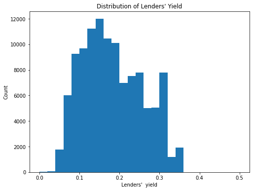

## How the Original Loan Amount is Distributed

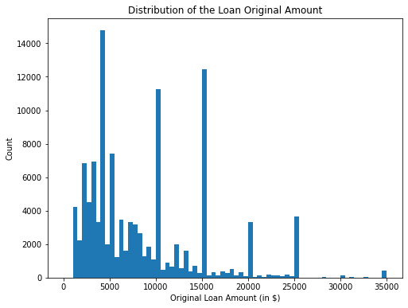

## Distribution of the Borrowers' Annual Percentage Cost

> The cost of borrowing peak 20% while the plot is fairly normal.

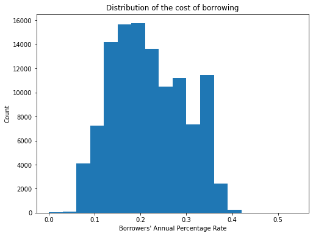

## Lenders' Yield Vrs Borrowers' Annual Percentage Rate

> On the logarithmic scale, the lenders' yield and the borrower annual percentage rate indicates a strong postive correlation (0.99). As borrower's rate increases, lenders' yield increases. The chart also indicates a slightly reduced rate of increment after it reaches 20% annual percentage rate. At that point the lenders' yield also begin to increase gradually from 15%. High borrowers' annual percentage rates depict high risky investment hence could explain increasing lenders' yield with increasing borrowers' rates.

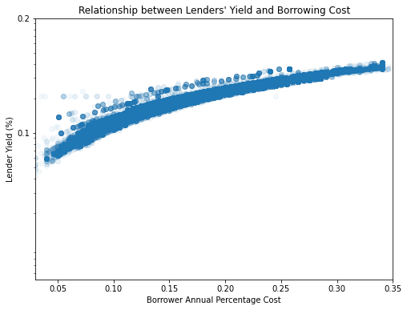

## Lenders' Yield Vrs Estimated Losss

> Though not strong as the borrowers' rate, the estimated loss also signifies an important relationship with the lenders' yield. A few points reflect no relationship but generally the impact of the estimated is strong (0.83). The estimated loss predicted on the loan investment will generally raise lenders' expectations of good returns to enable them invest. We see that higher estimated loss is associated with higher lender yield as shown in the graph.

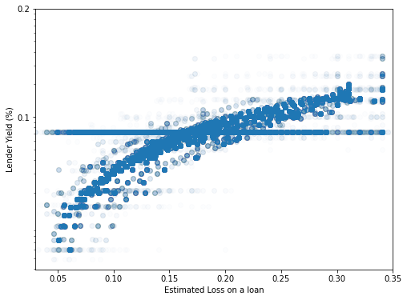

## Lenders' Yield by Ratings and Home ownership

> In plotting the lenders' yield and the prosper rating with whether a borrower is a home owner or not, the plot indicates that the ordered prosper ratings has a strong relationship with the yield that lenders get. Loans that are rated lowest have a highest yield, up to 31% returns to investors. Highly rated loans turns to have lower returns.

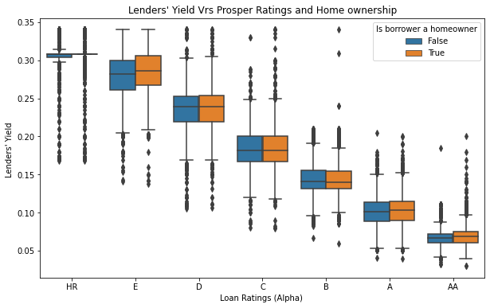